# Multivariate Adaptive Regression Splines

2023-12-28

## Summary of the model

All models presented until now are based on the linear regression model, and as such have strong assumptions about the underlying variables. Either these variables are assumed to follow a linear model, or a transformation of thse variables is.

In order to find such a representation, an algorithm is run in succession. In each iteration the modelled variable is broken down into two lines that are joint at a cutpoint value. This cutpoint value and the slope of such lines is searched so as to minimise the sum of squared errors (SSE) with respect to the original variable.

The result of this search will be a non-linear equation made of piecewise linear functions that models the original variable, with low SSE. Since this process can be run for as many data points the original dataset has, there is a trade-off with the complexity of the process, and knots that do not add significant value are removed through an evaluation process.

## Fitting a MARS model

We’ll start by loading the tidyverse metapackage, while calling every other package by name as usual.

```r
library(tidyverse)
```

We’ll fit the Ames house dataset using the mars model.

```r
data(ames, package = "modeldata")

set.seed(123)

ames_split_01 <- ames %>% rsample::initial_split(
    prop = 0.7,
    strata = Sale_Price)

ames_train_01 <- ames_split_01 %>%
    rsample::training()

ames_test_01 <- ames_split_01 %>%
    rsample::testing()

rs_01 <- ames_train_01 %>%
    rsample::vfold_cv(
        v = 10)
```

The model requires that all predictors are numerical, so encoding of factor predictors is required. This is done automatically by the model, but we will do it with a recipe.

```r
recipe_01 <-
    recipes::recipe(
        data = ames_train_01,
        Sale_Price ~ .)

recipe_02 <-
    recipe_01 %>%
    recipes::step_dummy(
        recipes::all_nominal_predictors())
```

Since the original MARS algorithm is proprietary, there is a freely available implementation named earth in R.

The parsnip mars model specification requires three parameters as stated in the [documentation](https://parsnip.tidymodels.org/reference/details_mars_earth.html).

```r
model_01 <-
    parsnip::mars(
        num_terms = tune(),
        prod_degree = 1L,
        prune_method = "backward") %>%
    parsnip::set_engine("earth") %>%
    parsnip::set_mode("regression")
```

We can create now a workflow with the recipe preprocessor and the model specification.

```r
wf_01 <-
    workflows::workflow(
        preprocessor = recipe_02,
        spec = model_01)
```

### Model tuning

Since we’ve set the `num_terms` parameter for tuning, we can look into it to understand the range of values under consideration.

```r
wf_01 %>%
    workflows::extract_parameter_set_dials()
```

```
## Collection of 1 parameters for tuning
##
##  identifier      type    object
##   num_terms num_terms nparam[+]
```

```r
wf_01 %>%
    workflows::extract_parameter_dials("num_terms")
```

```
## # Model Terms (quantitative)
## Range: [2, 5]
```

We’ll set a broader range for the number of terms.

```r
params_01 <-
    wf_01 %>%
    workflows::extract_parameter_set_dials() %>%
    update(
        "num_terms" = dials::num_terms(c(2, 200)))

params_01 %>%
    dials::extract_parameter_dials("num_terms")
```

```
## # Model Terms (quantitative)
## Range: [2, 200]
```

We can now create a grid using the `dials` package.

```r
grid_01 <-
    params_01 %>%
    dials::grid_regular(
        levels = 10)

control_grid_01 <-
    tune::control_grid(
        verbose = TRUE)
```

We can finally tune the model.

```r
metrics_01 <-
    yardstick::metric_set(
    yardstick::rmse,
    yardstick::rsq)

mars_tune_01 <-
    wf_01 %>%
    tune::tune_grid(
        resamples = rs_01,
        grid = grid_01,
        metrics = metrics_01,
        control = control_grid_01)
```

[output not shown]

[output not shown]

[output not shown]

[output not shown]

[output not shown]

[output not shown]

[output not shown]

[output not shown]

[output not shown]

[output not shown]

[output not shown]

[output not shown]

[output not shown]

[output not shown]

[output not shown]

[output not shown]

[output not shown]

[output not shown]

[output not shown]

[output not shown]

[output not shown]

[output not shown]

[output not shown]

[output not shown]

[output not shown]

[output not shown]

[output not shown]

[output not shown]

[output not shown]

[output not shown]

[output not shown]

[output not shown]

[output not shown]

[output not shown]

[output not shown]

[output not shown]

[output not shown]

[output not shown]

[output not shown]

[output not shown]

[output not shown]

[output not shown]

[output not shown]

[output not shown]

[output not shown]

[output not shown]

[output not shown]

[output not shown]

[output not shown]

[output not shown]

[output not shown]

[output not shown]

[output not shown]

[output not shown]

[output not shown]

[output not shown]

[output not shown]

[output not shown]

[output not shown]

[output not shown]

### Finalise the model

```r
best_param_01 <-
    mars_tune_01 %>%
    tune::select_best(
        metric = "rmse")

wf_02 <-
    wf_01 %>%
    tune::finalize_workflow(
        parameters = best_param_01)
```

We fit the last model

```r
wf_03 <-
    wf_02 %>%
    tune::last_fit(
        split = ames_split_01)
```

We evaluate the performance of the model against the test set.

```r
wf_03 %>%
    tune::collect_metrics()
```

```
## # A tibble: 2 × 4
##   .metric .estimator .estimate .config
##   <chr>   <chr>          <dbl> <chr>
## 1 rmse    standard   27688.    Preprocessor1_Model1
## 2 rsq     standard       0.877 Preprocessor1_Model1
```

## Understand the model

We’ve fit the model. Now we can ask about the features that are more relevant for the model, as well as how the model has processed the variables.

```r
fit_engine_01 <-
    wf_03 %>%
    workflows::extract_fit_engine()

fit_engine_01
```

```
## Selected 43 of 50 terms, and 31 of 276 predictors (nprune=46)
## Termination condition: RSq changed by less than 0.001 at 50 terms
## Importance: Gr_Liv_Area, Total_Bsmt_SF, Year_Built, Year_Remod_Add, Bsmt_Unf_SF, Garage_Cars, Kitchen_AbvGr, Second_Flr_SF, Roof_Matl_WdShngl, Neighborhood_Northridge_Heights, Neighborhood_Stone_Brook, Functional_Typ, Fireplaces, Full_Bath, Condition_2_PosA, Neighborhood_Crawford, ...
## Number of terms at each degree of interaction: 1 42 (additive model)
## GCV 589964720    RSS 1.110624e+12    GRSq 0.9086478    RSq 0.9159879
```

The model `earth` doesn’t include an implementation of the `tidy` function. Alternatively the `summary` function provides the model coefficients.

```r
fit_engine_01 %>%
    summary(
        details = TRUE)
```

```
## Call: earth(formula=..y~., data=data, pmethod=~"backward", keepxy=TRUE, degree=~1L, nprune=~46L)
##
##                                 coefficients
## (Intercept)                       206981.126
## Neighborhood_Somerset              18549.235
## Neighborhood_Northridge_Heights    35524.171
## Neighborhood_Crawford              21520.354
## Neighborhood_Northridge            26027.225
## Neighborhood_Stone_Brook           49329.909
## Neighborhood_Green_Hills          105264.750
## Condition_2_PosA                   92650.671
## Overall_Cond_Fair                 -31645.324
## Overall_Cond_Below_Average        -19495.986
## Overall_Cond_Average               -9402.337
## Roof_Matl_WdShngl                 108662.810
## Bsmt_Exposure_Gd                   15052.830
## Functional_Typ                     21700.432
## Sale_Type_New                      16993.214
## Sale_Condition_Normal              12924.147
## h(6600-Lot_Area)                      -4.627
## h(Lot_Area-6600)                       0.270
## h(2002-Year_Built)                  -370.065
## h(Year_Built-2002)                  2481.984
## h(1974-Year_Remod_Add)               206.830
## h(Year_Remod_Add-1974)               637.547
## h(Mas_Vnr_Area-89)                    19.602
## h(915-BsmtFin_SF_2)                   16.374
## h(BsmtFin_SF_2-915)                  157.275
## h(1656-Bsmt_Unf_SF)                   22.911
## h(Total_Bsmt_SF-1372)                 69.324
## h(2223-Total_Bsmt_SF)                -28.717
## h(Total_Bsmt_SF-2223)                -52.532
## h(Second_Flr_SF-1427)                478.744
## h(Gr_Liv_Area-1734)                   31.570
## h(3194-Gr_Liv_Area)                  -50.916
## h(Gr_Liv_Area-3194)                 -198.107
## h(3-Full_Bath)                     -4924.613
## h(Full_Bath-3)                   -110323.182
## h(4-Bedroom_AbvGr)                  4261.990
## h(Bedroom_AbvGr-4)                -13949.492
## h(2-Kitchen_AbvGr)                 25887.257
## h(2-Fireplaces)                    -6970.843
## h(2-Garage_Cars)                   -4176.228
## h(Garage_Cars-2)                   19846.656
## h(Screen_Porch-53)                    62.942
## h(Longitude- -93.6572)           -119165.128
##
## Selected 43 of 50 terms, and 31 of 276 predictors (nprune=46)
## Termination condition: RSq changed by less than 0.001 at 50 terms
## Importance: Gr_Liv_Area, Total_Bsmt_SF, Year_Built, Year_Remod_Add, Bsmt_Unf_SF, Garage_Cars, Kitchen_AbvGr, Second_Flr_SF, Roof_Matl_WdShngl, Neighborhood_Northridge_Heights, Neighborhood_Stone_Brook, Functional_Typ, Fireplaces, Full_Bath, Condition_2_PosA, Neighborhood_Crawford, ...
## Number of terms at each degree of interaction: 1 42 (additive model)
## GCV 589964720    RSS 1.110624e+12    GRSq 0.9086478    RSq 0.9159879
```

The `earth` package includes the function `evimp` to understand the importance of variables under three different criteria implemented natively by the package. These criteria are:

```
- `nsubsets` - How many model subsets include the variable.
- `rss` - Sum of residual squares. The model implements a measure of improvement over this variable.
- `gcv` - Generalized Cross Validation. A measure of the performance over the model over unseen data.
```

```r
fit_engine_01 %>%
    earth::evimp(
        trim = FALSE)
```

```
##                                                              nsubsets   gcv    rss
## Gr_Liv_Area                                                        42 100.0  100.0
## Total_Bsmt_SF                                                      40  51.6   52.0
## Year_Built                                                         39  61.0>  61.2>
## Year_Remod_Add                                                     39  43.7   44.3
## Bsmt_Unf_SF                                                        39  43.7   44.3
## Garage_Cars                                                        38  40.8   41.4
## Kitchen_AbvGr                                                      36  34.8   35.4
## Second_Flr_SF                                                      35  32.8   33.4
## Roof_Matl_WdShngl                                                  31  26.2   26.9
## Neighborhood_Northridge_Heights                                    31  26.1   26.9
## Neighborhood_Stone_Brook                                           31  26.1   26.9
## Functional_Typ                                                     29  23.1   23.9
## Fireplaces                                                         28  21.6   22.5
## Full_Bath                                                          27  20.4   21.3
## Condition_2_PosA                                                   26  19.3   20.2
## Neighborhood_Crawford                                              25  18.5   19.3
## Neighborhood_Northridge                                            24  17.7   18.6
## Lot_Area                                                           23  16.9   17.7
## Neighborhood_Somerset                                              22  16.1   17.0
## Bsmt_Exposure_Gd                                                   21  15.0   16.0
## Sale_Type_New                                                      19  13.4   14.3
## Sale_Condition_Normal                                              19  13.4   14.3
## Neighborhood_Green_Hills                                           19  13.2   14.1
## Overall_Cond_Fair                                                  16  11.2   12.2
## Bedroom_AbvGr                                                      15  10.5   11.5
## Screen_Porch                                                       13   9.1   10.1
## Overall_Cond_Below_Average                                         12   8.4    9.4
## Overall_Cond_Average                                               11   7.8    8.8
## Mas_Vnr_Area                                                        8   5.8    6.8
## BsmtFin_SF_2                                                        7   5.1    6.1
## Longitude                                                           3   2.8    3.6
## Lot_Frontage-unused                                                 0   0.0    0.0
## BsmtFin_SF_1-unused                                                 0   0.0    0.0
## First_Flr_SF-unused                                                 0   0.0    0.0
## Bsmt_Full_Bath-unused                                               0   0.0    0.0
## Bsmt_Half_Bath-unused                                               0   0.0    0.0
## Half_Bath-unused                                                    0   0.0    0.0
## TotRms_AbvGrd-unused                                                0   0.0    0.0
## Garage_Area-unused                                                  0   0.0    0.0
```

[output cut: 222 more lines]

```
## Misc_Feature_Othr-unused                                            0   0.0    0.0
## Misc_Feature_Shed-unused                                            0   0.0    0.0
## Misc_Feature_TenC-unused                                            0   0.0    0.0
## Sale_Type_Con-unused                                                0   0.0    0.0
## Sale_Type_ConLD-unused                                              0   0.0    0.0
## Sale_Type_ConLI-unused                                              0   0.0    0.0
## Sale_Type_ConLw-unused                                              0   0.0    0.0
## Sale_Type_CWD-unused                                                0   0.0    0.0
## Sale_Type_Oth-unused                                                0   0.0    0.0
## Sale_Type_VWD-unused                                                0   0.0    0.0
## Sale_Type_WD.-unused                                                0   0.0    0.0
## Sale_Condition_AdjLand-unused                                       0   0.0    0.0
## Sale_Condition_Alloca-unused                                        0   0.0    0.0
## Sale_Condition_Family-unused                                        0   0.0    0.0
## Sale_Condition_Partial-unused                                       0   0.0    0.0
```

The function `vip` can show similar results.

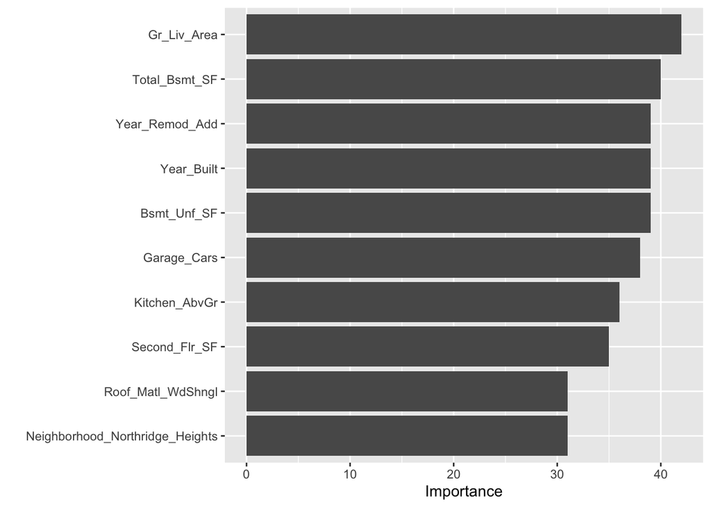

```r
fit_engine_01 %>%
    vip::vip()
```

The function `plotmo` can also build a graph that shows how each response varies with the predictions.

[output not shown]

[output cut: 23 more lines]

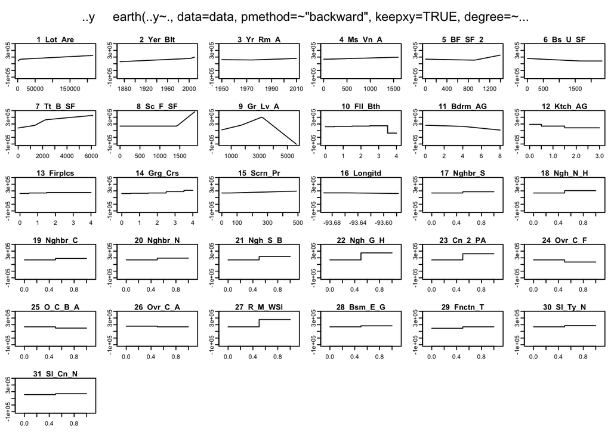

```r
fit_engine_01 %>%
    plotmo()
```